# A random modular network

# Global order parameters

\begin{equation} \rho = \frac{1}{N}\sum_{j=1}^N e^{\mathbf{i}\theta_j(t)} \end{equation}

```python
op1 = global_order_parameter_spacetime(spacetime[com[0]]).mean()
op2 = global_order_parameter_spacetime(spacetime[com[1]]).mean()
op3 = global_order_parameter_spacetime(spacetime[com[2]]).mean()
op = global_order_parameter_spacetime(spacetime).mean()

print "order parameter  of community 1: {} \
                 \n\t\t of community 2: {} \n\t\t of community 3: {} \
                 \n\t\t of the whole network: {} ".format(op1, op2, op3, op)
```

```
order parameter  of community 1: 0.95258980127
		 of community 2: 0.180455638763
		 of community 3: 0.948778847584
		 of the whole network: 0.726217543789
```

# Local order parameter for one time snapshot

\begin{equation} \rho_i = \frac{1}{2\delta}\sum_{j=i-\delta}^{i+\delta} e^{\mathbf{i}\theta_j(t)} \end{equation}

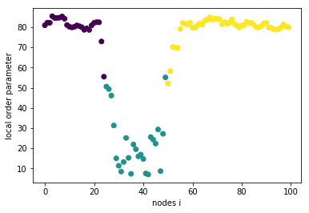

```python
lop = local_order_parameter_space(snapshot, order=5)

plt.clf()
plt.scatter(nodes_id, lop, c=membership, cmap=plt.cm.viridis)
plt.ylabel("local order parameter")
plt.xlabel("nodes i")
plt.show()
```

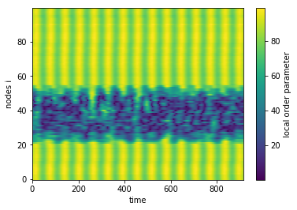

```python
lopsp = local_order_parameter_spacetime(spacetime, order=5)

plt.clf()
cb = plt.imshow(lopsp, aspect='auto', origin="lower", cmap=plt.cm.viridis)
cbar = plt.colorbar(cb)
cbar.ax.set_ylabel("local order parameter")
plt.xlabel("time")
plt.ylabel("nodes i")
plt.show()
```

# Mean phase velocity

\begin{equation} \Omega_i = \frac{2 \pi K_i}{\Delta T}\,, \end{equation} where $K_i$ is the number of periods of the $i$-th oscillator during a time interval $\Delta T$.

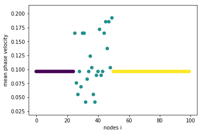

```python
omega = mean_phase_velocity_spacetime(spacetime, order=5)

plt.clf()
plt.scatter(nodes_id, omega, c=membership, cmap=plt.cm.viridis)
plt.xlabel("nodes i")
plt.ylabel("mean phase velocity")
plt.show()
```

# Local curvature index

\begin{equation} \hat{D}\theta_i(t) := \sum_{j=i-\delta}^{j=i+\delta} \!\left[\theta_j(t) - \theta_i(t)\right]\, \end{equation}

The norm of the operator $\hat{D}$ is the local curvature index and:

- $ \|\hat{D}\{\theta_{i_\text{coh}}(t)\}\|\approx 0 $ in the coherent clusters
- $\|\hat{D}\{\theta_{i_\text{incoh}}(t)\}\|\neq 0$ and has pronounced fluctuations in the incoherent clusters.

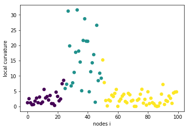

```python
local_curv = local_curvature_space(snapshot, order=5)

plt.clf()
plt.scatter(nodes_id, local_curv, c=membership, cmap=plt.cm.viridis)
plt.xlabel("nodes i")
plt.ylabel("local curvature")
plt.show()
```

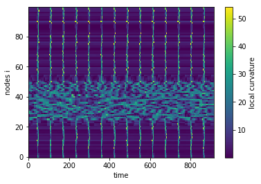

```python
lcsp = local_curvature_spacetime(spacetime, order=5)

plt.clf()
cb = plt.imshow(lcsp, aspect='auto', origin="lower", cmap=plt.cm.viridis)
cbar = plt.colorbar(cb)
cbar.ax.set_ylabel("local curvature")
plt.xlabel("time")
plt.ylabel("nodes i")
plt.show()
```

# Coherence in time and in space

- Metastabilite index $\lambda$:

\begin{equation} \lambda = {\langle \sigma_{\textbf{met}} \rangle}_{C_m} \end{equation} where \begin{equation} \sigma_{\textbf{met}}(m)=\frac{1}{T-1}\sum_{t=1}^T(\rho_m(t)-{\langle \rho_m \rangle}_T)^2 \end{equation}

- Chimera-like index $\chi$ \begin{equation} \chi={\langle \sigma_{\textbf{chi}} \rangle}_T, \end{equation} where \begin{equation} \sigma_{\textbf{chi}}(t)=\frac{1}{M-1}\sum_{m=1}^M(\rho_m(t)-{\langle \rho(t) \rangle}_M)^2 \end{equation}

```python
# Chimera-like index
chi = chimera_index(spacetime, membership)
print "chimera-like index:",chi
```

```
chimera-like index: 0.022003867393472935
```

```python
# Metastability index
lam = metastability_index(spacetime, membership)
print "metastability index:" ,lam
```

```
metastability index: 0.0031985509411240755
```

```python
if chi > lam: print "chimera-like states"
if chi < lam: print "metastable states"
```

```
chimera-like states
```